- Home
- Munge
- Aggregate
- Visualize
- Time Series

# Practical Data Analysis with Python - Visualization

## Data visualization

Let's make some visualizations as part of the iterative process of data munging, aggregating, and visualizing. Visualizations help us understand the data better. At best, exploratory data visualization inspires questions and informs our analysis while identifying trends and patterns to further learn from the data.

We will see that displaying similar information in a variety of ways and using different types and styles of plots can reveal even more about the data.

```python
%matplotlib inline
```

```python
import numpy as np
import pandas as pd
from datetime import datetime, time
```

```python
from ggplot import *
import seaborn as sns
```

```python
print pd.__version__
print np.__version__
```

```
0.14.1
1.9.0
```

```python
%load_ext ipycache
```

### Exploratory data visualization

In practical data analysis, we want to make our plots in the most efficient and succinct way possible following an iterative data analysis process. A visualization will form more questions that lead to further visualzations using pandas, ggplot, and seaborn. In exploratory visualization, grouping & aggregating data and plotting are part of that iterative process. We want to learn from our data what further visualzations will provide insight and hopefully lead to more statistical questions and more visualizations.

Mean temperature

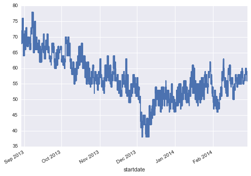

```python
#mean temperature
dmerge4.mean_temperature_f.plot()
```

### Plotting time-series data

#### Daily average duration for the first six months of operation of the bike sharing system

In this plot, we can see that most trips were under sixty minutes and fluctuated for the most part between under twenty minutes up to around fifty minutes depending on the time of day.

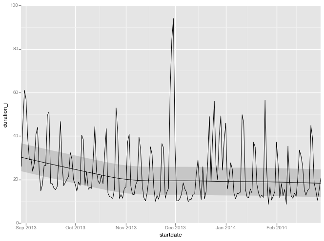

```python
#daily average duration for the first six months of operation
print (ggplot(aes(x='startdate', y='duration_i'), data=daily_means) + \
    geom_line()) + geom_smooth()
```

#### Daily average mean temperature

Since San Francisco doesn't have typically harsh winters, temperature did not seem to have much effect on length of bicycle trips

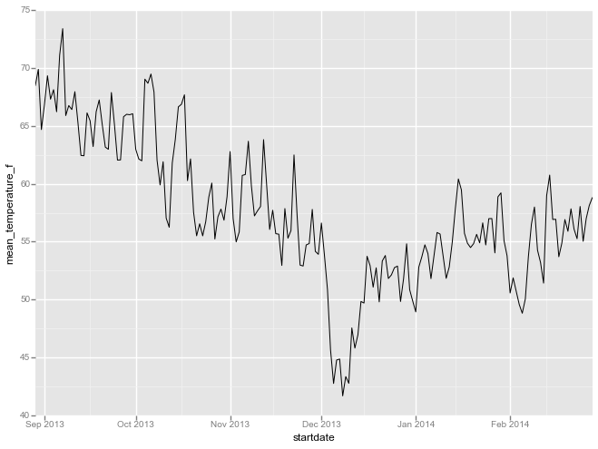

```python
print (ggplot(aes(x='startdate', y='mean_temperature_f'), data=daily_means) + \
    geom_line())
```

#### Mean temperatures for the entire dataset

This plot is included here to compare the above graph with plotting the entire dataset. Taking the daily mean in the prevous plots allows us to consolidate multiple observations on a single day to give a less noisy graph. In this graph, every single observation is plotted. Taking the daily mean is a way to see the trend more cleanly and also will allow for further analysis on a daily data.

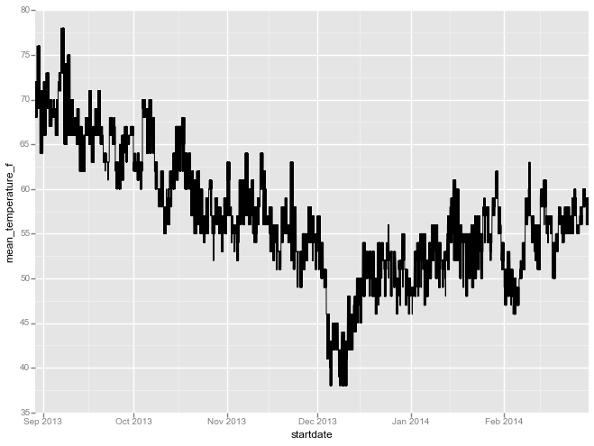

```python
print (ggplot(aes(x='startdate', y='mean_temperature_f'), data=dmerge4) + \
    geom_line())
```

#### Average duration on a monthly basis for the six month period

The monthly duration takes away some of the noise indicated by the daily data. We do actually see a declining trend as we go from Autumn to Winter.

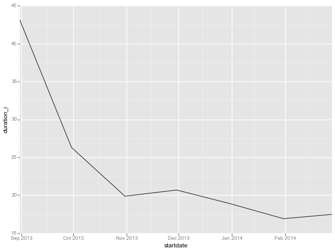

```python
print (ggplot(aes(x='startdate', y='duration_i'), data=monthly_means) + \
    geom_line())
```

Remember that we concatenated two time series intervals for the morning and evening commute. We can now see in this graph that the average duration by month is mostly higher in the evening than in the morning. Keeping in mind that August was the first month of operation, the plot also indicates that on average, the bicycle was returned to a dock within the initial thirty minute from start time from September to February.

#### Average duration by month facetted by morning and evening commuting hours

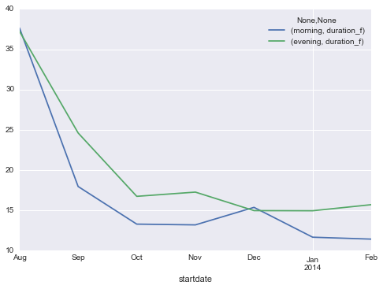

```python
concatenated.plot()
```

#### Average duration at 4pm for the six month period

What's really nice about Pandas time series functionality is that we can also look at plots at specific times as well. Here is a plot of total duration at 4pm for the entire six month period. The plot indicates that a user had a bicycle for a really long time at 4pm in October but mostly the trip durations were under fifty minutes.

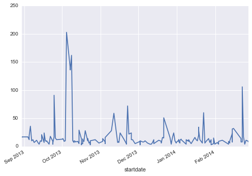

```python
#total duration at particular time
dmerge4.duration_i.at_time(time(16, 0)).plot()
```

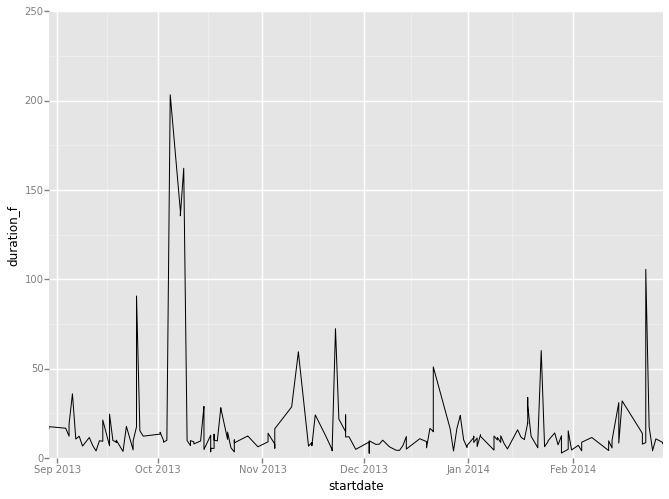

```python
four_pm_df=pd.DataFrame(dmerge4.duration_f.at_time(time(16, 0))).reset_index()
ggplot(four_pm_df,aes(x='startdate',y='duration_f')) + geom_line()

#duration at 4pm for everyday the entire six month period
```

#### Average duration by time of day

Durations are shorter during the morning and evening commuting hours and slightly higher during the mid-day and at night. The data also indicates that people are keeping bicycles for a longer period of time after midnight until four am.

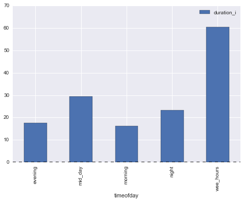

```python
dmerge4.groupby('timeofday')[['duration_i']].mean().plot(kind='bar')
```

#### Dodged bar plot of average duration by landmark and time of day

Duration in San Francisco is the shortest and this is also the area that the highest number of docks in the dataset as shown in the grouping and aggregating section of the analysis.

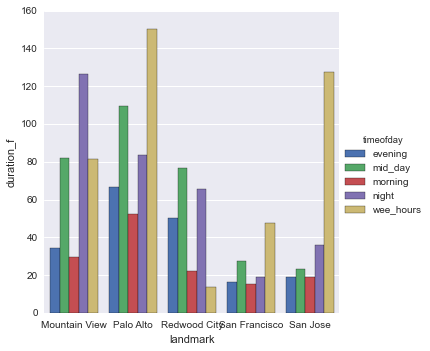

```python
sns.factorplot("landmark", "duration_f", "timeofday", data=timelandmark);
```

#### Dockcounts by landmark and duration

It is evident in this plot that dockcounts were lowest in Palo Alto where average durations were also the highest.

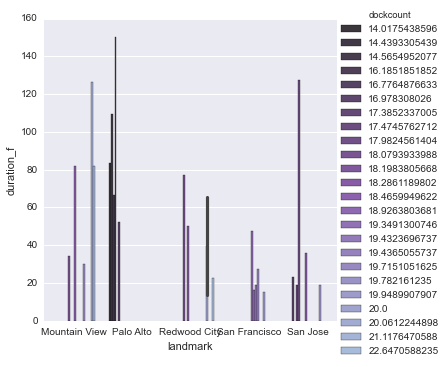

```python
sns.factorplot("landmark", "duration_f", "dockcount", data=timelandmark,palette="BuPu_d")
```

#### Average duration by landmark faceted by timeofday

This plot is nice because it allows us to visually see the differences in duration by landmark by categorical time of day.

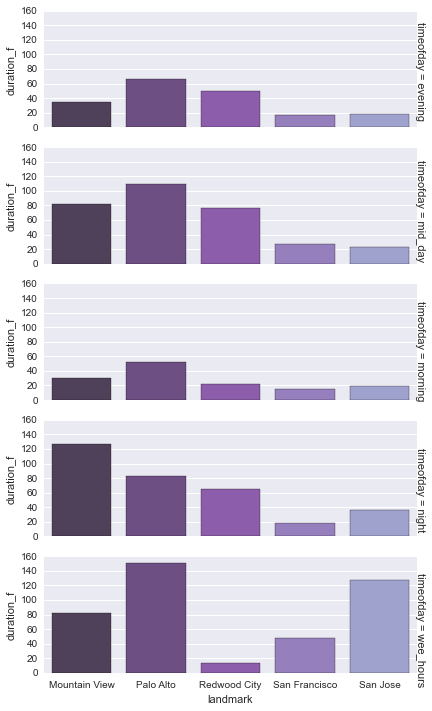

```python
sns.factorplot("landmark","duration_f", data=timelandmark, row="timeofday",
               margin_titles=True, aspect=3, size=2,palette="BuPu_d");
```

#### Average duration for each landmark faceted by month

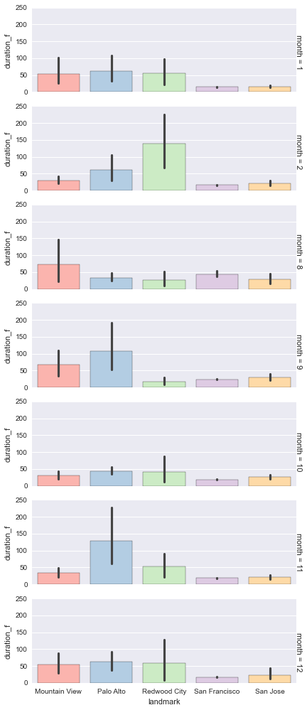

```python
#faceted by month
sns.factorplot("landmark","duration_f", data=dmerge4, row="month",
               margin_titles=True, aspect=3, size=2,palette="Pastel1");
```

This plot indicates plots for mean,minimum,and maximum summary statistics

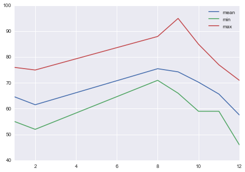

```python
dmerge4.groupby(dmerge4.index.month)['max_temperature_f'].agg(['mean','min','max']).plot()
```

#### Mean and minimum duration by hour of the day

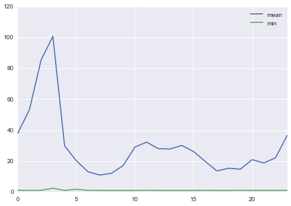

```python
dmerge4.groupby(dmerge4.index.hour)['duration_f'].agg(['mean','min']).plot()
```

#### What are the average durations by day of the month?

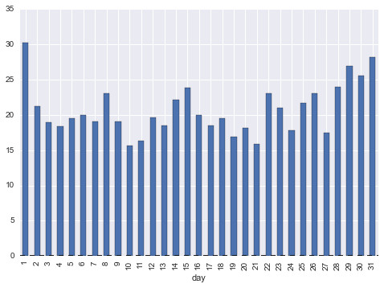

```python
day_means['duration_f'].plot(kind='bar')
```

#### In what month did the highest duration occur and what was the suscription type?

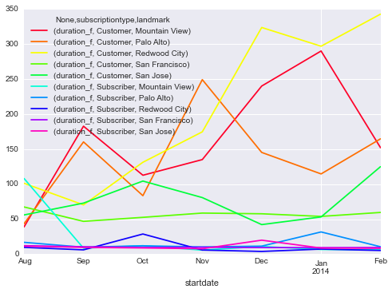

```python
dmerge4.groupby([pd.Grouper(freq='M',key='startdate'),"landmark","subscriptiontype"])[['duration_f']].mean().unstack().unstack().plot(colormap='gist_rainbow')
```

#### Dodged bar plots by month of average duration by landmark and subscription type

In December, January, and February, the highest average duration was for a customer in Redwood City

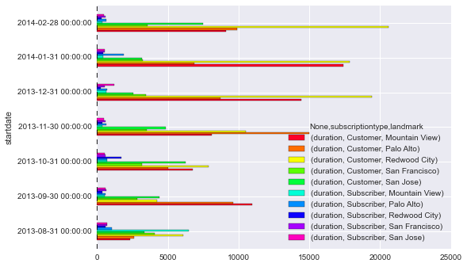

```python
three_grouper_unstack_twice = dmerge4.groupby([pd.Grouper(freq='M',key='startdate'),"landmark","subscriptiontype"])[['duration']].mean().unstack().unstack()
three_grouper_unstack_twice.plot(kind="barh",colormap='gist_rainbow')
#change color scheme
```

#### Monthly average duration by landmark

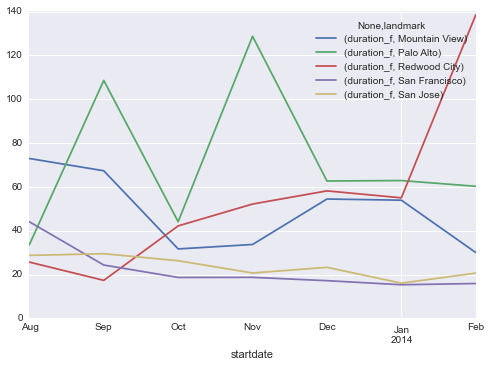

```python
grouperl = dmerge4.groupby([pd.Grouper(freq='M',key='startdate'),'landmark']).mean()[['duration_f']]
grouperl.unstack().plot()
```

#### Dodged bar plot of monthly average duration by landmark

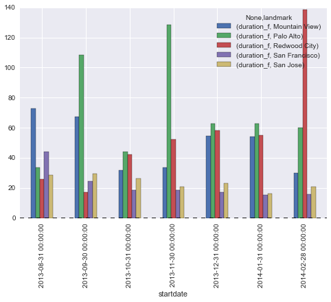

```python
grouperl.unstack().plot(kind="bar")
```

#### Average monthly duration faceted by time of day

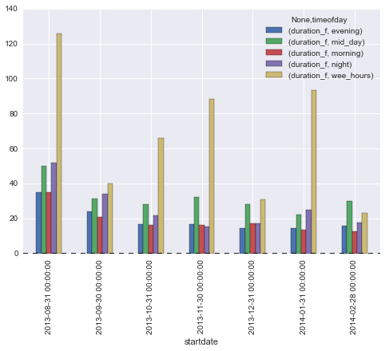

```python
#avg duration monthly faceted by time of day
grouperm = dmerge4.groupby([pd.Grouper(freq='M',key='startdate'),'timeofday']).mean()[['duration_f']]
grouperm.unstack().plot(kind="bar")
```

#### Average duration by landmark

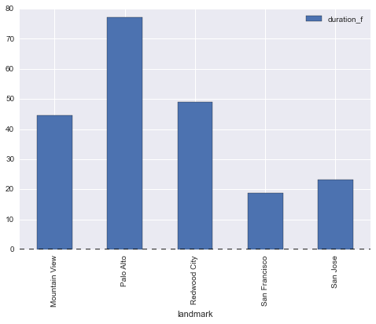

```python
dmerge4.groupby("landmark").mean()[['duration_f']].plot(kind='bar')
```

#### Average duration by hour of the day for the entire six month period

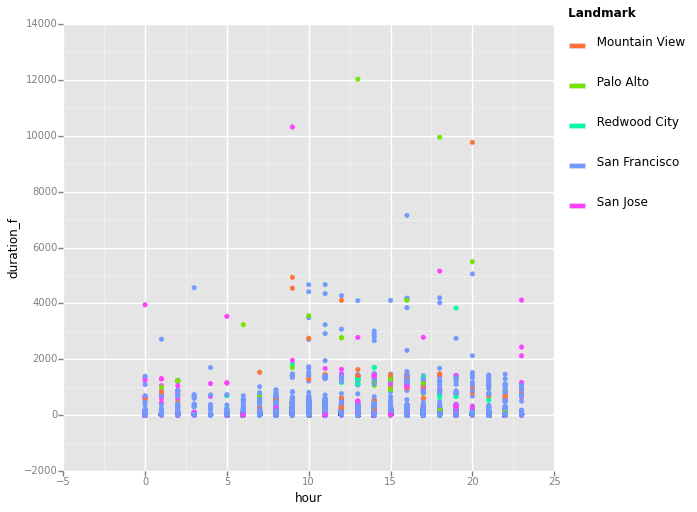

```python
ggplot(dmerge4, aes('hour', 'duration_f',color='landmark')) + geom_point(stat="identity")

    #how to add legend
```

#### Boxplot of monthly average duration by landmark

Subscribers for the most part are below sixty minute durations while customers have higher durations and the widest range of duration in Redwood City followed by Mountain View.

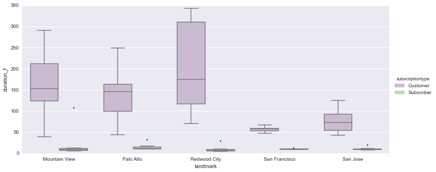

```python
three_grouper = dmerge4.groupby([pd.Grouper(freq='M',key='startdate'),"landmark","subscriptiontype"])[['duration_f']].mean().reset_index()
import seaborn as sns
sns.factorplot("landmark", "duration_f", "subscriptiontype", three_grouper, kind="box",
                   palette="PRGn", aspect=2.25)
```

#### Distribution of mean temperature

It doesn't get too warm or too cold in Northern California between August and February.

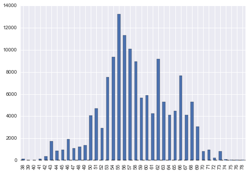

```python
dmerge4['mean_temperature_f'].value_counts().sort_index().plot(kind='bar')
```

#### Average duration and standard deviation for subscription type of Customer by landmark

Bar plot of average duration by landmark and subscription type. In this case, we only wanted to compare duration by one type of customer.

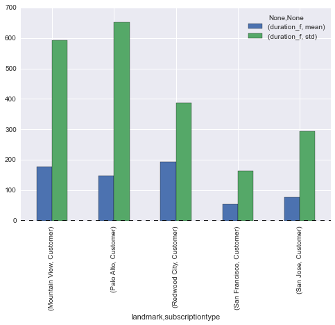

```python
dmerge4.groupby(['landmark','subscriptiontype'])[['duration_f']].agg([np.mean, np.std]).query('subscriptiontype == "Customer"').plot(kind="bar")
```

Note, this is the exact same plot as above except that the unstacking does not affect the result because we specified the subscription type value.

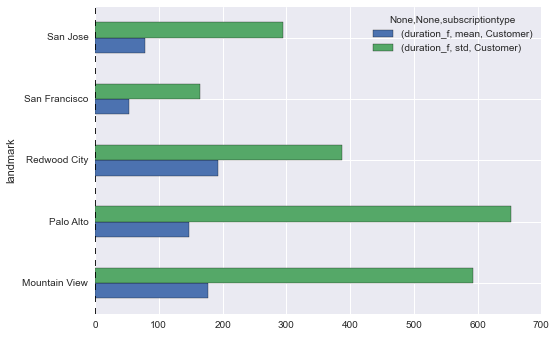

```python
dmerge4.groupby(['landmark','subscriptiontype'])[['duration_f']].agg([np.mean, np.std]).query('subscriptiontype == "Customer"').unstack().plot(kind="barh")
```

#### Average duration by subscription type

Looking at the mean duration by subscription type shows that subscribers are on average within the thirty minutes while ‘customers’ often exceed that time period. Remember that seventy-nine percent of total observations in the dataset are subscribers. Subscribers have an annual membership while customers are defined as either twenty-four hour or three day pass.

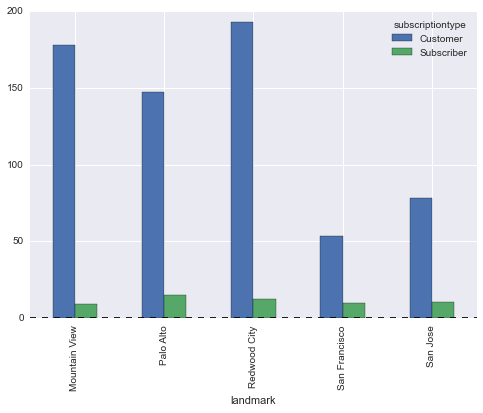

```python
dmerge4.groupby(['landmark','subscriptiontype'])['duration_f'].mean().unstack().plot(kind="bar")
```

#### Plot that indicates the differences in average duration between subscribers and customers by landmark

We love this plot. It gives a very clear idea of the differences in average duration between customers and subscribers with dodged plots by landmark.

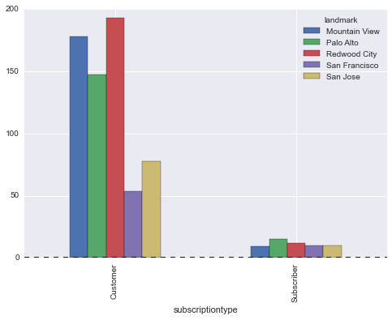

```python
dmerge4.groupby(['subscriptiontype','landmark'])['duration_f'].mean().unstack().plot(kind="bar")
```

#### Number of observations in the dataset by landmark and subscription type

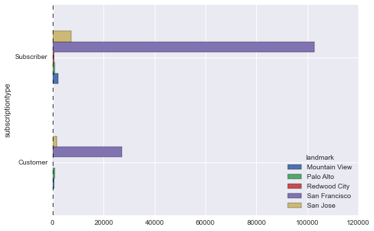

```python
dmerge4.groupby(['subscriptiontype', 'landmark']).size().unstack().plot(kind='barh')
```